# Analyzing Presidential Campaign Spending in Battleground-State Counties

# 1. Data Cleaning and Wrangling

The spending and election dataframes have been merged on 'recipient_state' and 'County?'. Spending is only included from the general election and not primary election campaigns. We will first merge and clean the dataframes to create more comprehensive election datasets.

```python
import pandas as pd
import numpy as np
import statsmodels.api as sm
import matplotlib.pyplot as plt
import seaborn as sns
from sklearn.model_selection import train_test_split
from sklearn.linear_model import LogisticRegression
from sklearn.metrics import accuracy_score, confusion_matrix
```

```python
h2016 = pd.read_csv(r"C:\Users\Aaron\Desktop\ModelREady\ModelREady\General Election\merged_2016hgen")
t2016 = pd.read_csv(r"C:\Users\Aaron\Desktop\ModelREady\ModelREady\General Election\merged_2016tgen")
b2020 = pd.read_csv(r"C:\Users\Aaron\Desktop\ModelREady\ModelREady\General Election\merged_2020bgen")
t2020 = pd.read_csv(r"C:\Users\Aaron\Desktop\ModelREady\ModelREady\General Election\merged_2020tgen")
```

```python
h2016 = h2016.drop(columns=['Unnamed: 0.1', 'County?', 'Unnamed: 0', 'State'])
t2016 = t2016.drop(columns=['Unnamed: 0.1', 'County?', 'Unnamed: 0', 'State'])
b2020 = b2020.drop(columns=['Unnamed: 0.1', 'County?', 'Unnamed: 0', 'State'])
t2020 = t2020.drop(columns=['Unnamed: 0.1', 'County?', 'Unnamed: 0', 'State'])
```

```python
h2016 = h2016.rename(columns={'disbursement_amount': 'disbursement_clinton'})
t2016 = t2016.rename(columns={'disbursement_amount': 'disbursement_trump'})
b2020 = b2020.rename(columns={'disbursement_amount': 'disbursement_biden'})
t2020 = t2020.rename(columns={'disbursement_amount': 'disbursement_trump'})
```

We will now merge the datasets and drop the columns indicating vote numbers in favor of vote percentages. Starting with the 2016 dataframes:

```python
merged_2016 = h2016.merge(
    t2016[['recipient_state', 'County', 'disbursement_trump', 'Trump_Percentage', 'Clinton_Percentage']],
    on=['recipient_state', 'County'],
    how='outer'
)
```

```python
merged_2016 = merged_2016.fillna(0)
```

```python
merged_2016['trump_percentage'] = merged_2016[['Trump_Percentage_x', 'Trump_Percentage_y']].max(axis=1)
merged_2016['clinton_percentage'] = merged_2016[['Clinton_Percentage_x', 'Clinton_Percentage_y']].max(axis=1)
```

```python
merged_2016 = merged_2016.drop(columns=['G16PRERTRU', 'G16PREDCLI', 'OtherVotes', 'TotalVotes', 'Trump_Percentage_x', 'Clinton_Percentage_x', 'Trump_Percentage_y', 'Clinton_Percentage_y'])
```

Now for the 2020 dataframes:

```python
merged_2020 = b2020.merge(
    t2020[['recipient_state', 'County', 'disbursement_trump', 'Trump_Percentage', 'Biden_Percentage']],
    on=['recipient_state', 'County'],
    how='outer'
)
```

```python
merged_2020 = merged_2020.fillna(0)
```

```python
merged_2020['trump_percentage'] = merged_2020[['Trump_Percentage_x', 'Trump_Percentage_y']].max(axis=1)
merged_2020['biden_percentage'] = merged_2020[['Biden_Percentage_x', 'Biden_Percentage_y']].max(axis=1)
```

```python
merged_2020 = merged_2020.drop(columns=['G20PREDBID', 'G20PRERTRU', 'OtherVotes', 'TotalVotes', 'Trump_Percentage_x', 'Biden_Percentage_x', 'Trump_Percentage_y', 'Biden_Percentage_y'])
```

For the last step, we will be creating our disbursement percentage and win/loss county majority vote variables.

```python
merged_2016['clinton_win'] = (merged_2016['clinton_percentage'] > merged_2016['trump_percentage']).astype(int)
merged_2016['trump_win'] = (merged_2016['trump_percentage'] > merged_2016['clinton_percentage']).astype(int)
```

```python
merged_2020['biden_win'] = (merged_2020['biden_percentage'] > merged_2020['trump_percentage']).astype(int)
merged_2020['trump_win'] = (merged_2020['trump_percentage'] > merged_2020['biden_percentage']).astype(int)
```

```python
merged_2016['disbursement_total'] = merged_2016['disbursement_trump'] + merged_2016['disbursement_clinton']
merged_2020['disbursement_total'] = merged_2020['disbursement_trump'] + merged_2020['disbursement_biden']
```

```python
merged_2016['disbursement_trump_pct'] = np.where(
    merged_2016['disbursement_total'] == 0, 0, merged_2016['disbursement_trump'] / merged_2016['disbursement_total']
)
merged_2016['disbursement_clinton_pct'] = np.where(
    merged_2016['disbursement_total'] == 0, 0, merged_2016['disbursement_clinton'] / merged_2016['disbursement_total']
)
```

```python
merged_2020['disbursement_trump_pct'] = np.where(
    merged_2020['disbursement_total'] == 0, 0, merged_2020['disbursement_trump'] / merged_2020['disbursement_total']
)
merged_2020['disbursement_biden_pct'] = np.where(
    merged_2020['disbursement_total'] == 0, 0, merged_2020['disbursement_biden'] / merged_2020['disbursement_total']
)
```

```python
merged_2020.head()
```

|  | recipient_state | disbursement_biden | County | disbursement_trump | trump_percentage | biden_percentage | biden_win | trump_win | disbursement_total | disbursement_trump_pct | disbursement_biden_pct |
| --- | --- | --- | --- | --- | --- | --- | --- | --- | --- | --- | --- |
| 0 | AZ | 0.00 | cochise | 2005.29 | 58.828298 | 39.264088 | 0 | 1 | 2005.29 | 1.000000 | 0.000000 |
| 1 | AZ | 0.00 | coconino | 1000.00 | 36.919969 | 61.002839 | 1 | 0 | 1000.00 | 1.000000 | 0.000000 |
| 2 | AZ | 111740.77 | maricopa | 2836514.25 | 48.142924 | 50.324059 | 1 | 0 | 2948255.02 | 0.962099 | 0.037901 |
| 3 | AZ | 0.00 | mohave | 19574.50 | 75.032484 | 23.723583 | 0 | 1 | 19574.50 | 1.000000 | 0.000000 |
| 4 | AZ | 5280.63 | pima | 17344.46 | 39.922982 | 58.605449 | 1 | 0 | 22625.09 | 0.766603 | 0.233397 |

```python
merged_2016.head()
```

|  | recipient_state | disbursement_clinton | County | disbursement_trump | trump_percentage | clinton_percentage | clinton_win | trump_win | disbursement_total | disbursement_trump_pct | disbursement_clinton_pct |
| --- | --- | --- | --- | --- | --- | --- | --- | --- | --- | --- | --- |
| 0 | AZ | 0.00 | gila | 25092.57 | 62.989118 | 31.103709 | 0 | 1 | 25092.57 | 1.000000 | 0.000000 |
| 1 | AZ | 38896.46 | maricopa | 1393134.20 | 47.668376 | 44.832999 | 0 | 1 | 1432030.66 | 0.972838 | 0.027162 |
| 2 | AZ | 8990.56 | pima | 40309.17 | 39.708756 | 53.282658 | 1 | 0 | 49299.73 | 0.817635 | 0.182365 |
| 3 | AZ | 0.00 | pinal | 437.50 | 56.210921 | 36.969107 | 0 | 1 | 437.50 | 1.000000 | 0.000000 |
| 4 | AZ | 0.00 | yavapai | 9789.90 | 62.324159 | 31.096549 | 0 | 1 | 9789.90 | 1.000000 | 0.000000 |

# 2. Linear Regression Modeling

For this notebook, I will create ordinary least-squares (OLS) linear regression models using disbursement_percentage and disbursement_(candidate) as independent variables for each candidate with candidate vote percentage as our dependent variable. This should provide insight on how campaign finance allocation in each county within battleground states affects vote share.

# 2016 Election: County Vote Share as a Function of Disbursement Amount

```python
trump_y = merged_2016['trump_percentage']
clinton_y = merged_2016['clinton_percentage']

Xh = sm.add_constant(merged_2016['disbursement_clinton'])
Xt = sm.add_constant(merged_2016['disbursement_trump'])
```

```python
trump_model = sm.OLS(trump_y, Xt).fit()
clinton_model = sm.OLS(clinton_y, Xh).fit()
```

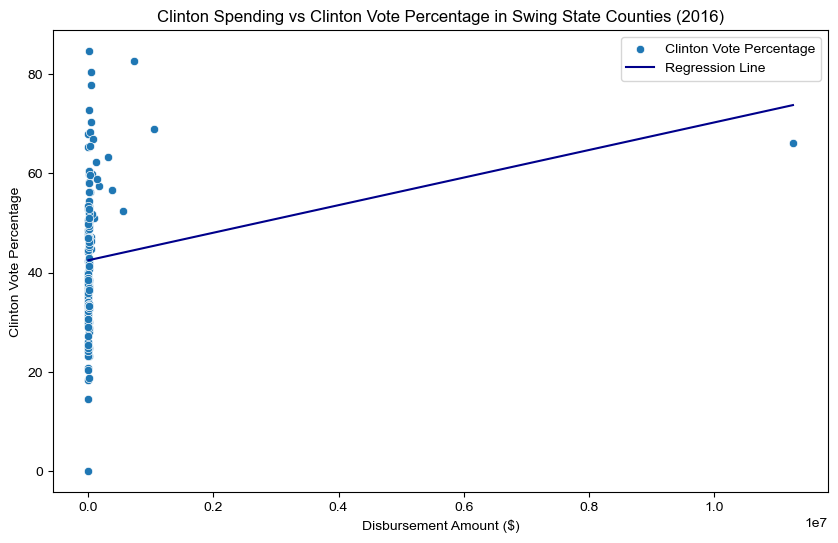

```python
plt.rcParams['font.family'] = 'Arial'
plt.figure(figsize=(10, 6))
sns.scatterplot(x=merged_2016['disbursement_clinton'], y=merged_2016['clinton_percentage'], label='Clinton Vote Percentage')
sns.lineplot(x=merged_2016['disbursement_clinton'], y=clinton_model.predict(Xh), color='darkblue', label='Regression Line')
plt.title('Clinton Spending vs Clinton Vote Percentage in Swing State Counties (2016)')
plt.xlabel('Disbursement Amount ($)')
plt.ylabel('Clinton Vote Percentage')
plt.legend()
plt.show()
```

```python
print(clinton_model.summary())
```

```
                            OLS Regression Results
==============================================================================
Dep. Variable:     clinton_percentage   R-squared:                       0.032
Model:                            OLS   Adj. R-squared:                  0.025
Method:                 Least Squares   F-statistic:                     4.775
Date:                Tue, 05 Nov 2024   Prob (F-statistic):             0.0305
Time:                        08:35:07   Log-Likelihood:                -594.81
No. Observations:                 146   AIC:                             1194.
Df Residuals:                     144   BIC:                             1200.
Df Model:                           1
Covariance Type:            nonrobust
========================================================================================
                           coef    std err          t      P>|t|      [0.025      0.975]
----------------------------------------------------------------------------------------
const                   42.4744      1.193     35.593      0.000      40.116      44.833
disbursement_clinton  2.772e-06   1.27e-06      2.185      0.030    2.65e-07    5.28e-06
==============================================================================
Omnibus:                        5.994   Durbin-Watson:                   1.913
Prob(Omnibus):                  0.050   Jarque-Bera (JB):                5.530
Skew:                           0.436   Prob(JB):                       0.0630
Kurtosis:                       3.385   Cond. No.                     9.47e+05
==============================================================================

Notes:
[1] Standard Errors assume that the covariance matrix of the errors is correctly specified.
[2] The condition number is large, 9.47e+05. This might indicate that there are
strong multicollinearity or other numerical problems.
```

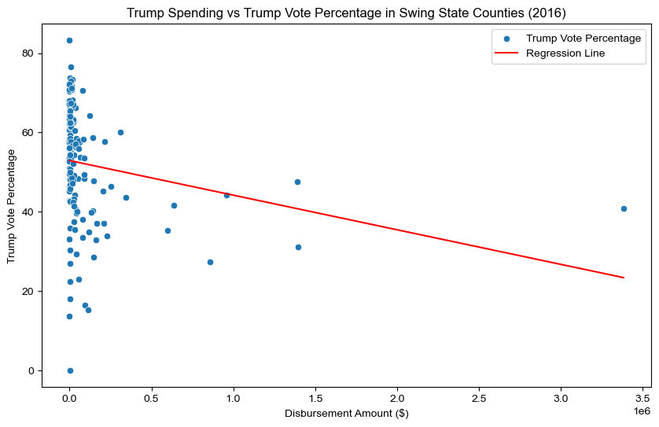

```python
plt.rcParams['font.family'] = 'Arial'
plt.figure(figsize=(10, 6))
sns.scatterplot(x=merged_2016['disbursement_trump'], y=merged_2016['trump_percentage'], label='Trump Vote Percentage')
sns.lineplot(x=merged_2016['disbursement_trump'], y=trump_model.predict(Xt), color='red', label='Regression Line')
plt.title('Trump Spending vs Trump Vote Percentage in Swing State Counties (2016)')
plt.xlabel('Disbursement Amount ($)')
plt.ylabel('Trump Vote Percentage')
plt.legend()
plt.show()
```

```python
print(trump_model.summary())
```

```
                            OLS Regression Results
==============================================================================
Dep. Variable:       trump_percentage   R-squared:                       0.042
Model:                            OLS   Adj. R-squared:                  0.035
Method:                 Least Squares   F-statistic:                     6.277
Date:                Tue, 05 Nov 2024   Prob (F-statistic):             0.0133
Time:                        08:42:08   Log-Likelihood:                -595.41
No. Observations:                 146   AIC:                             1195.
Df Residuals:                     144   BIC:                             1201.
Df Model:                           1
Covariance Type:            nonrobust
======================================================================================
                         coef    std err          t      P>|t|      [0.025      0.975]
--------------------------------------------------------------------------------------
const                 52.9223      1.239     42.700      0.000      50.472      55.372
disbursement_trump -8.717e-06   3.48e-06     -2.505      0.013   -1.56e-05   -1.84e-06
==============================================================================
Omnibus:                       16.548   Durbin-Watson:                   1.879
Prob(Omnibus):                  0.000   Jarque-Bera (JB):               18.645
Skew:                          -0.785   Prob(JB):                     8.94e-05
Kurtosis:                       3.776   Cond. No.                     3.71e+05
==============================================================================

Notes:
[1] Standard Errors assume that the covariance matrix of the errors is correctly specified.
[2] The condition number is large, 3.71e+05. This might indicate that there are
strong multicollinearity or other numerical problems.
```

# 2020 Election: County Vote Share as a Function of Disbursement Amount

```python
trump_y = merged_2020['trump_percentage']
biden_y = merged_2020['biden_percentage']

Xb = sm.add_constant(merged_2020['disbursement_biden'])
Xt = sm.add_constant(merged_2020['disbursement_trump'])
```

```python
trump_model2 = sm.OLS(trump_y, Xt).fit()
biden_model = sm.OLS(biden_y, Xb).fit()
```

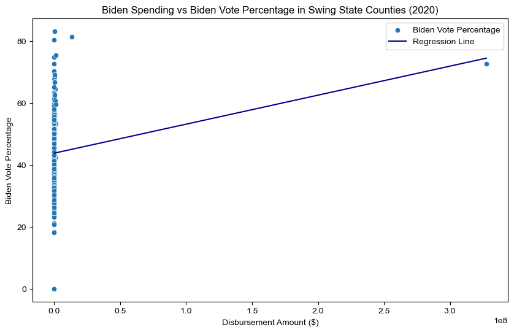

```python
plt.rcParams['font.family'] = 'Arial'
plt.figure(figsize=(10, 6))
sns.scatterplot(x=merged_2020['disbursement_biden'], y=merged_2020['biden_percentage'], label='Biden Vote Percentage')
sns.lineplot(x=merged_2020['disbursement_biden'], y=biden_model.predict(Xb), color='darkblue', label='Regression Line')
plt.title('Biden Spending vs Biden Vote Percentage in Swing State Counties (2020)')
plt.xlabel('Disbursement Amount ($)')
plt.ylabel('Biden Vote Percentage')
plt.legend()
plt.show()
```

```python
print(biden_model.summary())
```

```
                            OLS Regression Results
==============================================================================
Dep. Variable:       biden_percentage   R-squared:                       0.025
Model:                            OLS   Adj. R-squared:                  0.020
Method:                 Least Squares   F-statistic:                     4.668
Date:                Tue, 05 Nov 2024   Prob (F-statistic):             0.0320
Time:                        08:52:57   Log-Likelihood:                -747.76
No. Observations:                 184   AIC:                             1500.
Df Residuals:                     182   BIC:                             1506.
Df Model:                           1
Covariance Type:            nonrobust
======================================================================================
                         coef    std err          t      P>|t|      [0.025      0.975]
--------------------------------------------------------------------------------------
const                 43.8309      1.047     41.856      0.000      41.765      45.897
disbursement_biden   9.36e-08   4.33e-08      2.161      0.032    8.12e-09    1.79e-07
==============================================================================
Omnibus:                        3.642   Durbin-Watson:                   2.083
Prob(Omnibus):                  0.162   Jarque-Bera (JB):                4.370
Skew:                          -0.003   Prob(JB):                        0.112
Kurtosis:                       3.755   Cond. No.                     2.42e+07
==============================================================================

Notes:
[1] Standard Errors assume that the covariance matrix of the errors is correctly specified.
[2] The condition number is large, 2.42e+07. This might indicate that there are
strong multicollinearity or other numerical problems.
```

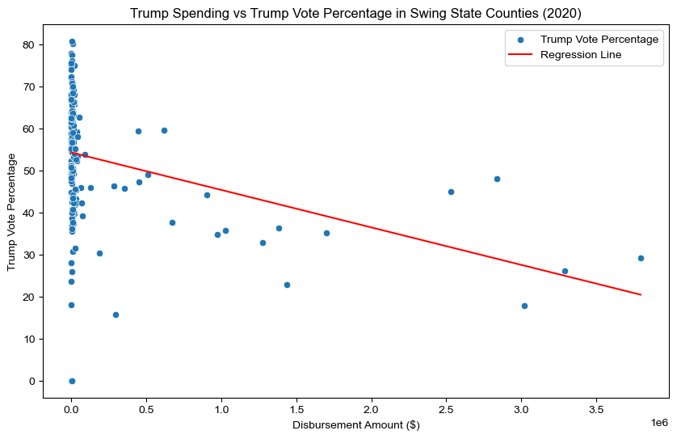

```python
plt.rcParams['font.family'] = 'Arial'
plt.figure(figsize=(10, 6))
sns.scatterplot(x=merged_2020['disbursement_trump'], y=merged_2020['trump_percentage'], label='Trump Vote Percentage')
sns.lineplot(x=merged_2020['disbursement_trump'], y=trump_model2.predict(Xt), color='red', label='Regression Line')
plt.title('Trump Spending vs Trump Vote Percentage in Swing State Counties (2020)')
plt.xlabel('Disbursement Amount ($)')
plt.ylabel('Trump Vote Percentage')
plt.legend()
plt.show()
```

```python
print(trump_model2.summary())
```

```
                            OLS Regression Results
==============================================================================
Dep. Variable:       trump_percentage   R-squared:                       0.113
Model:                            OLS   Adj. R-squared:                  0.109
Method:                 Least Squares   F-statistic:                     23.29
Date:                Tue, 05 Nov 2024   Prob (F-statistic):           2.94e-06
Time:                        08:55:08   Log-Likelihood:                -745.21
No. Observations:                 184   AIC:                             1494.
Df Residuals:                     182   BIC:                             1501.
Df Model:                           1
Covariance Type:            nonrobust
======================================================================================
                         coef    std err          t      P>|t|      [0.025      0.975]
--------------------------------------------------------------------------------------
const                 54.3295      1.071     50.723      0.000      52.216      56.443
disbursement_trump -8.908e-06   1.85e-06     -4.826      0.000   -1.25e-05   -5.27e-06
==============================================================================
Omnibus:                       42.908   Durbin-Watson:                   1.918
Prob(Omnibus):                  0.000   Jarque-Bera (JB):               85.309
Skew:                          -1.097   Prob(JB):                     2.99e-19
Kurtosis:                       5.512   Cond. No.                     6.04e+05
==============================================================================

Notes:
[1] Standard Errors assume that the covariance matrix of the errors is correctly specified.
[2] The condition number is large, 6.04e+05. This might indicate that there are
strong multicollinearity or other numerical problems.
```

# 2016 Election: County Vote Share as a Function of Disbursement Percentage

```python
trump_y = merged_2016['trump_percentage']
clinton_y = merged_2016['clinton_percentage']

Xc = sm.add_constant(merged_2016['disbursement_clinton_pct'])
Xt = sm.add_constant(merged_2016['disbursement_trump_pct'])
```

```python
trump_model = sm.OLS(trump_y, Xt).fit()
clinton_model = sm.OLS(clinton_y, Xc).fit()
```

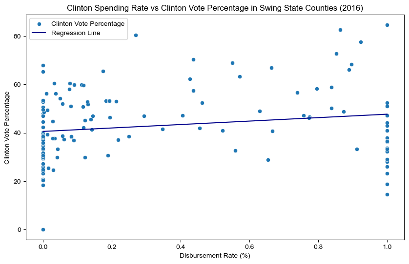

```python
plt.rcParams['font.family'] = 'Arial'
plt.figure(figsize=(10, 6))
sns.scatterplot(x=merged_2016['disbursement_clinton_pct'], y=merged_2016['clinton_percentage'], label='Clinton Vote Percentage')
sns.lineplot(x=merged_2016['disbursement_clinton_pct'], y=clinton_model.predict(Xc), color='darkblue', label='Regression Line')
plt.title('Clinton Spending Rate vs Clinton Vote Percentage in Swing State Counties (2016)')
plt.xlabel('Disbursement Rate (%)')
plt.ylabel('Clinton Vote Percentage')
plt.legend()
plt.show()
```

```python
print(clinton_model.summary())
```

```
                            OLS Regression Results
==============================================================================
Dep. Variable:     clinton_percentage   R-squared:                       0.036
Model:                            OLS   Adj. R-squared:                  0.029
Method:                 Least Squares   F-statistic:                     5.405
Date:                Tue, 05 Nov 2024   Prob (F-statistic):             0.0215
Time:                        09:10:00   Log-Likelihood:                -594.50
No. Observations:                 146   AIC:                             1193.
Df Residuals:                     144   BIC:                             1199.
Df Model:                           1
Covariance Type:            nonrobust
============================================================================================
                               coef    std err          t      P>|t|      [0.025      0.975]
--------------------------------------------------------------------------------------------
const                       40.5693      1.516     26.766      0.000      37.573      43.565
disbursement_clinton_pct     7.1165      3.061      2.325      0.021       1.066      13.167
==============================================================================
Omnibus:                        2.169   Durbin-Watson:                   1.896
Prob(Omnibus):                  0.338   Jarque-Bera (JB):                1.886
Skew:                           0.276   Prob(JB):                        0.389
Kurtosis:                       3.068   Cond. No.                         2.87
==============================================================================

Notes:
[1] Standard Errors assume that the covariance matrix of the errors is correctly specified.
```

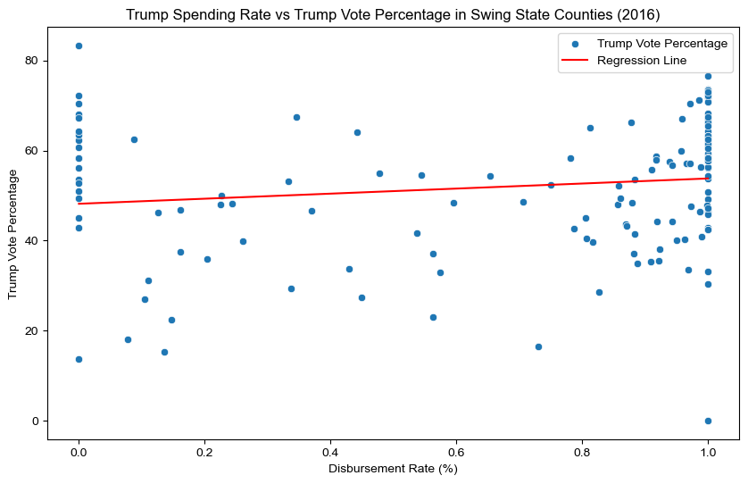

```python
plt.rcParams['font.family'] = 'Arial'
plt.figure(figsize=(10, 6))
sns.scatterplot(x=merged_2016['disbursement_trump_pct'], y=merged_2016['trump_percentage'], label='Trump Vote Percentage')
sns.lineplot(x=merged_2016['disbursement_trump_pct'], y=trump_model.predict(Xt), color='red', label='Regression Line')
plt.title('Trump Spending Rate vs Trump Vote Percentage in Swing State Counties (2016)')
plt.xlabel('Disbursement Rate (%)')
plt.ylabel('Trump Vote Percentage')
plt.legend()
plt.show()
```

```python
print(trump_model.summary())
```

```
                            OLS Regression Results
==============================================================================
Dep. Variable:       trump_percentage   R-squared:                       0.022
Model:                            OLS   Adj. R-squared:                  0.015
Method:                 Least Squares   F-statistic:                     3.253
Date:                Tue, 05 Nov 2024   Prob (F-statistic):             0.0734
Time:                        09:19:02   Log-Likelihood:                -596.89
No. Observations:                 146   AIC:                             1198.
Df Residuals:                     144   BIC:                             1204.
Df Model:                           1
Covariance Type:            nonrobust
==========================================================================================
                             coef    std err          t      P>|t|      [0.025      0.975]
------------------------------------------------------------------------------------------
const                     48.1831      2.462     19.570      0.000      43.317      53.049
disbursement_trump_pct     5.6120      3.112      1.804      0.073      -0.538      11.762
==============================================================================
Omnibus:                       10.752   Durbin-Watson:                   1.845
Prob(Omnibus):                  0.005   Jarque-Bera (JB):               10.930
Skew:                          -0.617   Prob(JB):                      0.00423
Kurtosis:                       3.524   Cond. No.                         3.95
==============================================================================

Notes:
[1] Standard Errors assume that the covariance matrix of the errors is correctly specified.
```

# 2020 Election: County Vote Share as a Function of Disbursement Percentage

```python
trump_y = merged_2020['trump_percentage']
biden_y = merged_2020['biden_percentage']

Xb = sm.add_constant(merged_2020['disbursement_biden_pct'])
Xt = sm.add_constant(merged_2020['disbursement_trump_pct'])
```

```python
trump_model2 = sm.OLS(trump_y, Xt).fit()
biden_model = sm.OLS(biden_y, Xb).fit()
```

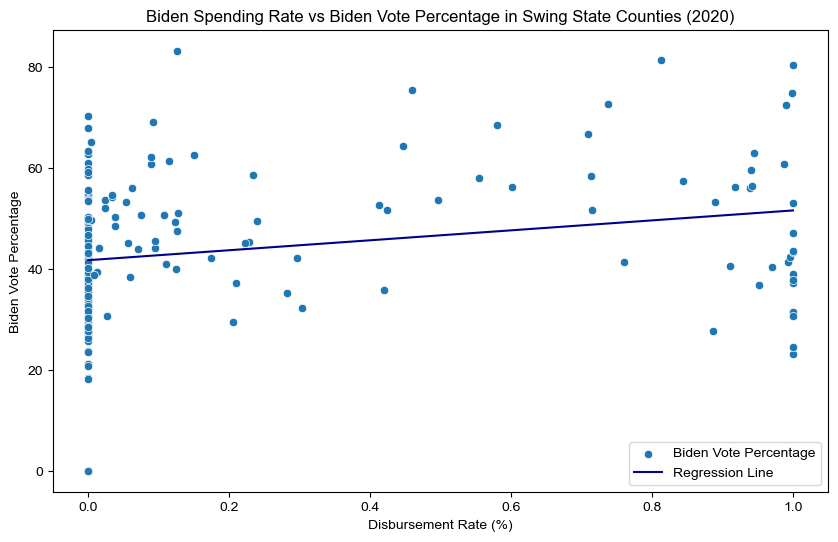

```python
plt.rcParams['font.family'] = 'Arial'
plt.figure(figsize=(10, 6))
sns.scatterplot(x=merged_2020['disbursement_biden_pct'], y=merged_2020['biden_percentage'], label='Biden Vote Percentage')
sns.lineplot(x=merged_2020['disbursement_biden_pct'], y=biden_model.predict(Xb), color='darkblue', label='Regression Line')
plt.title('Biden Spending Rate vs Biden Vote Percentage in Swing State Counties (2020)')
plt.xlabel('Disbursement Rate (%)')
plt.ylabel('Biden Vote Percentage')
plt.legend()
plt.show()
```

```python
print(biden_model.summary())
```

```
                            OLS Regression Results
==============================================================================
Dep. Variable:       biden_percentage   R-squared:                       0.063
Model:                            OLS   Adj. R-squared:                  0.057
Method:                 Least Squares   F-statistic:                     12.15
Date:                Tue, 05 Nov 2024   Prob (F-statistic):           0.000615
Time:                        09:31:59   Log-Likelihood:                -744.15
No. Observations:                 184   AIC:                             1492.
Df Residuals:                     182   BIC:                             1499.
Df Model:                           1
Covariance Type:            nonrobust
==========================================================================================
                             coef    std err          t      P>|t|      [0.025      0.975]
------------------------------------------------------------------------------------------
const                     41.7882      1.206     34.659      0.000      39.409      44.167
disbursement_biden_pct     9.8396      2.823      3.486      0.001       4.270      15.409
==============================================================================
Omnibus:                        2.326   Durbin-Watson:                   2.130
Prob(Omnibus):                  0.313   Jarque-Bera (JB):                2.104
Skew:                          -0.102   Prob(JB):                        0.349
Kurtosis:                       3.482   Cond. No.                         2.92
==============================================================================

Notes:
[1] Standard Errors assume that the covariance matrix of the errors is correctly specified.
```

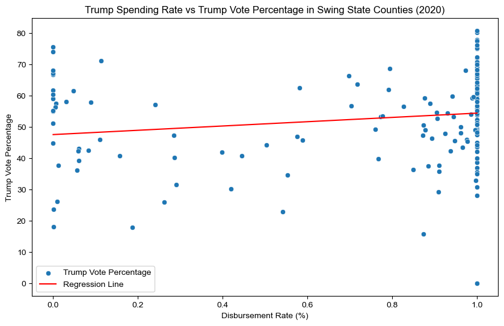

```python
plt.rcParams['font.family'] = 'Arial'
plt.figure(figsize=(10, 6))
sns.scatterplot(x=merged_2020['disbursement_trump_pct'], y=merged_2020['trump_percentage'], label='Trump Vote Percentage')
sns.lineplot(x=merged_2020['disbursement_trump_pct'], y=trump_model2.predict(Xt), color='red', label='Regression Line')
plt.title('Trump Spending Rate vs Trump Vote Percentage in Swing State Counties (2020)')
plt.xlabel('Disbursement Rate (%)')
plt.ylabel('Trump Vote Percentage')
plt.legend()
plt.show()
```

```python
print(trump_model2.summary())
```

```
                            OLS Regression Results
==============================================================================
Dep. Variable:       trump_percentage   R-squared:                       0.028
Model:                            OLS   Adj. R-squared:                  0.023
Method:                 Least Squares   F-statistic:                     5.317
Date:                Tue, 05 Nov 2024   Prob (F-statistic):             0.0222
Time:                        09:35:00   Log-Likelihood:                -753.64
No. Observations:                 184   AIC:                             1511.
Df Residuals:                     182   BIC:                             1518.
Df Model:                           1
Covariance Type:            nonrobust
==========================================================================================
                             coef    std err          t      P>|t|      [0.025      0.975]
------------------------------------------------------------------------------------------
const                     47.5969      2.541     18.730      0.000      42.583      52.611
disbursement_trump_pct     6.8534      2.972      2.306      0.022       0.989      12.718
==============================================================================
Omnibus:                       32.873   Durbin-Watson:                   1.980
Prob(Omnibus):                  0.000   Jarque-Bera (JB):               53.182
Skew:                          -0.941   Prob(JB):                     2.83e-12
Kurtosis:                       4.843   Cond. No.                         4.55
==============================================================================

Notes:
[1] Standard Errors assume that the covariance matrix of the errors is correctly specified.
```

# Discussion of Results

We generally see statistically significant correlation but weak explanation of variance. For the models using disbursement amount as independent variable, this is likely due to outliers. As for the models where disbursement rate is our independent variable, this is likely due to values on both ends of the axis where the candidates receive a range of values for vote share in each county where either 0 or 100% of campaign spending occurs by one party. The datasets will be modified and the resulting models will be explored in a separate notebook.

# 3. Logistic Regression Modeling

Having created binary outcome columns denoting a win/loss of county majority vote for each candidate, we will create Maximum Lkelihood Estimation (MLE) Logistic Regression models to assess how campaign disbursements and disbursement rates affect the probability of a candidate winning a majority vote in counties within battleground states.

# 2016 Election: Probability of County Majority Vote as a Function of Disbursement Amount

```python
X = merged_2016[['disbursement_clinton']]
y = merged_2016['clinton_win']
```

```python
X_train, X_test, y_train, y_test = train_test_split(X, y, test_size=0.3, random_state=42)
```

```python
X_train_C2016 = sm.add_constant(X_train)
X_test_C2016 = sm.add_constant(X_test)
```

```python
logit_modelC2016 = sm.Logit(y_train, X_train_C2016)
resultC2016 = logit_modelC2016.fit()
```

```
Optimization terminated successfully.
         Current function value: 0.488470
         Iterations 12
```

```python
y_predC2016 = resultC2016.predict(X_test_C2016)
y_pred_binaryC2016 = [1 if x >= 0.5 else 0 for x in y_predC2016]
```

```python
accuracyC2016 = accuracy_score(y_test, y_pred_binaryC2016)
conf_matrixC2016 = confusion_matrix(y_test, y_pred_binaryC2016)
```

```python
print(f"Accuracy: {accuracyC2016}")
print(f"Confusion Matrix: \n{conf_matrixC2016}")
```

```
Accuracy: 0.7727272727272727
Confusion Matrix:
[[29  1]
 [ 9  5]]
```

```python
logregC2016 = LogisticRegression(solver='liblinear')
logregC2016.fit(X, y)
```

```
LogisticRegression(solver='liblinear')
```

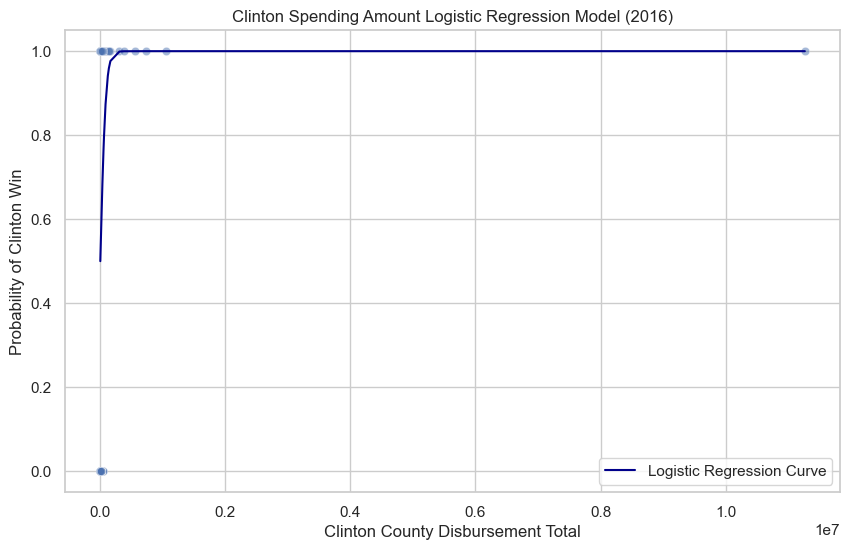

```python
sns.set(style='whitegrid')

plt.figure(figsize=(10, 6))

sns.scatterplot(data=merged_2016, x='disbursement_clinton', y='clinton_win', alpha=0.5)

X = np.sort(merged_2016['disbursement_clinton'])
predicted_probC2016 = logregC2016.predict_proba(X.reshape(-1, 1))[:, 1]

plt.plot(X, predicted_probC2016, color='darkblue', label='Logistic Regression Curve')

plt.title('Clinton Spending Amount Logistic Regression Model (2016)')
plt.xlabel('Clinton County Disbursement Total')
plt.ylabel('Probability of Clinton Win')
plt.legend()
plt.show()
```

```python
print(resultC2016.summary())
```

```
                           Logit Regression Results
==============================================================================
Dep. Variable:            clinton_win   No. Observations:                  102
Model:                          Logit   Df Residuals:                      100
Method:                           MLE   Df Model:                            1
Date:                Tue, 05 Nov 2024   Pseudo R-squ.:                  0.2476
Time:                        10:17:18   Log-Likelihood:                -49.824
converged:                       True   LL-Null:                       -66.223
Covariance Type:            nonrobust   LLR p-value:                 1.022e-08
========================================================================================
                           coef    std err          z      P>|z|      [0.025      0.975]
----------------------------------------------------------------------------------------
const                   -1.3975      0.289     -4.829      0.000      -1.965      -0.830
disbursement_clinton  7.194e-05   2.45e-05      2.936      0.003    2.39e-05       0.000
========================================================================================
```

```python
X = merged_2016[['disbursement_trump']]
y= merged_2016['trump_win']
```

```python
X_train, X_test, y_train, y_test = train_test_split(X, y, test_size=0.3, random_state=42)
```

```python
X_train_T2016 = sm.add_constant(X_train)
X_test_T2016 = sm.add_constant(X_test)
```

```python
logit_modelT2016 = sm.Logit(y_train, X_train_T2016)
resultT2016 = logit_modelT2016.fit()
```

```
Optimization terminated successfully.
         Current function value: 0.606256
         Iterations 6
```

```python
y_predT2016 = resultT2016.predict(X_test_T2016)
y_pred_binaryT2016 = [1 if x >= 0.5 else 0 for x in y_predT2016]
```

```python
accuracyT2016 = accuracy_score(y_test, y_pred_binaryT2016)
conf_matrixT2016 = confusion_matrix(y_test, y_pred_binaryT2016)
```

```python
print(f"Accuracy: {accuracyT2016}")
print(f"Confusion Matrix: \n{conf_matrixT2016}")
```

```
Accuracy: 0.6818181818181818
Confusion Matrix:
[[ 1 14]
 [ 0 29]]
```

```python
logregT2016 = LogisticRegression(solver='liblinear')
logregT2016.fit(X, y)
```

```
LogisticRegression(solver='liblinear')
```

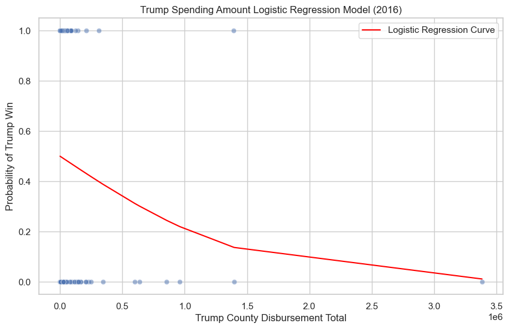

```python
sns.set(style='whitegrid')

plt.figure(figsize=(10, 6))

sns.scatterplot(data=merged_2016, x='disbursement_trump', y='trump_win', alpha=0.5)

X = np.sort(merged_2016['disbursement_trump'])
predicted_probT2016 = logregT2016.predict_proba(X.reshape(-1, 1))[:, 1]

plt.plot(X, predicted_probT2016, color='red', label='Logistic Regression Curve')

plt.title('Trump Spending Amount Logistic Regression Model (2016)')
plt.xlabel('Trump County Disbursement Total')
plt.ylabel('Probability of Trump Win')
plt.legend()
plt.show()
```

```python
print(resultT2016.summary())
```

```
                           Logit Regression Results
==============================================================================
Dep. Variable:              trump_win   No. Observations:                  102
Model:                          Logit   Df Residuals:                      100
Method:                           MLE   Df Model:                            1
Date:                Tue, 05 Nov 2024   Pseudo R-squ.:                 0.06622
Time:                        10:36:30   Log-Likelihood:                -61.838
converged:                       True   LL-Null:                       -66.223
Covariance Type:            nonrobust   LLR p-value:                  0.003061
======================================================================================
                         coef    std err          z      P>|z|      [0.025      0.975]
--------------------------------------------------------------------------------------
const                  0.8845      0.237      3.735      0.000       0.420       1.349
disbursement_trump -3.155e-06   1.43e-06     -2.202      0.028   -5.96e-06   -3.47e-07
======================================================================================
```

# 2020 Election: Probability of County Majority Vote as a Function of Disbursement Amount

```python
X = merged_2020[['disbursement_biden']]
y = merged_2020['biden_win']
```

```python
X_train, X_test, y_train, y_test = train_test_split(X, y, test_size=0.3, random_state=42)
```

```python
X_train_B2020 = sm.add_constant(X_train)
X_test_B2020 = sm.add_constant(X_test)
```

```python
logit_modelB2020 = sm.Logit(y_train, X_train_B2020)
resultB2020 = logit_modelB2020.fit()
```

```
Optimization terminated successfully.
         Current function value: 0.520219
         Iterations 16
```

```python
y_predB2020 = resultB2020.predict(X_test_B2020)
y_pred_binaryB2020 = [1 if x >= 0.5 else 0 for x in y_predB2020]
```

```python
accuracyB2020 = accuracy_score(y_test, y_pred_binaryB2020)
conf_matrixB2020 = confusion_matrix(y_test, y_pred_binaryB2020)
```

```python
print(f"Accuracy: {accuracyB2020}")
print(f"Confusion Matrix: \n{conf_matrixB2020}")
```

```
Accuracy: 0.75
Confusion Matrix:
[[34  2]
 [12  8]]
```

```python
logregB2020 = LogisticRegression(solver='liblinear')
logregB2020.fit(X, y)
```

```
LogisticRegression(solver='liblinear')
```

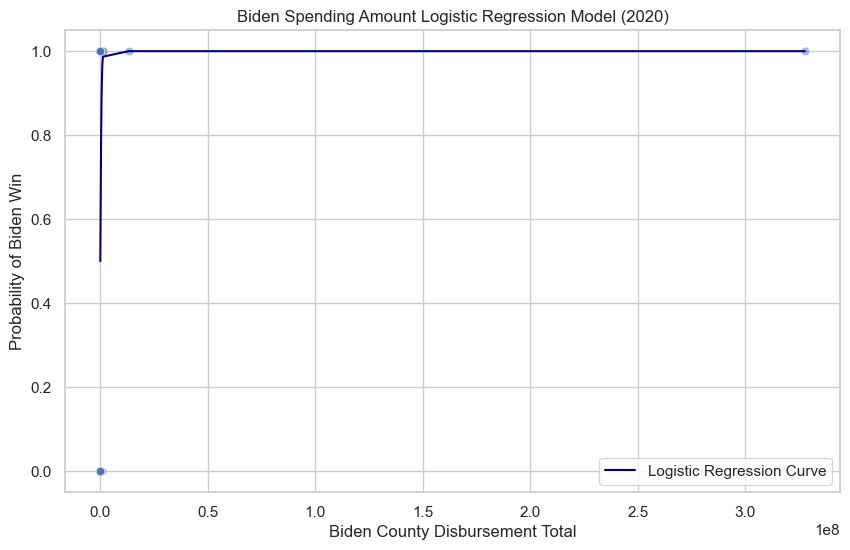

```python
sns.set(style='whitegrid')

plt.figure(figsize=(10, 6))

sns.scatterplot(data=merged_2020, x='disbursement_biden', y='biden_win', alpha=0.5)

X = np.sort(merged_2020['disbursement_biden'])
predicted_probB2020 = logregB2020.predict_proba(X.reshape(-1, 1))[:, 1]

plt.plot(X, predicted_probB2020, color='darkblue', label='Logistic Regression Curve')

plt.title('Biden Spending Amount Logistic Regression Model (2020)')
plt.xlabel('Biden County Disbursement Total')
plt.ylabel('Probability of Biden Win')
plt.legend()
plt.show()
```

```python
print(resultB2020.summary())
```

```
                           Logit Regression Results
==============================================================================
Dep. Variable:              biden_win   No. Observations:                  128
Model:                          Logit   Df Residuals:                      126
Method:                           MLE   Df Model:                            1
Date:                Tue, 05 Nov 2024   Pseudo R-squ.:                  0.2137
Time:                        10:54:17   Log-Likelihood:                -66.588
converged:                       True   LL-Null:                       -84.680
Covariance Type:            nonrobust   LLR p-value:                 1.795e-09
======================================================================================
                         coef    std err          z      P>|z|      [0.025      0.975]
--------------------------------------------------------------------------------------
const                 -1.0471      0.223     -4.690      0.000      -1.485      -0.610
disbursement_biden  5.469e-05   2.15e-05      2.546      0.011    1.26e-05    9.68e-05
======================================================================================
```

```python
X = merged_2020[['disbursement_trump']]
y= merged_2020['trump_win']
```

```python
X_train, X_test, y_train, y_test = train_test_split(X, y, test_size=0.3, random_state=42)
```

```python
X_train_T2020 = sm.add_constant(X_train)
X_test_T2020 = sm.add_constant(X_test)
```

```python
logit_modelT2020 = sm.Logit(y_train, X_train_T2020)
resultT2020 = logit_modelT2020.fit()
```

```
Optimization terminated successfully.
         Current function value: 0.587365
         Iterations 8
```

```python
y_predT2020 = resultT2020.predict(X_test_T2020)
y_pred_binaryT2020 = [1 if x >= 0.5 else 0 for x in y_predT2020]
```

```python
accuracyT2020 = accuracy_score(y_test, y_pred_binaryT2020)
conf_matrixT2020 = confusion_matrix(y_test, y_pred_binaryT2020)
```

```python
print(f"Accuracy: {accuracyT2020}")
print(f"Confusion Matrix: \n{conf_matrixT2020}")
```

```
Accuracy: 0.7142857142857143
Confusion Matrix:
[[ 5 15]
 [ 1 35]]
```

```python
logregT2020 = LogisticRegression(solver='liblinear')
logregT2020.fit(X, y)
```

```
LogisticRegression(solver='liblinear')
```

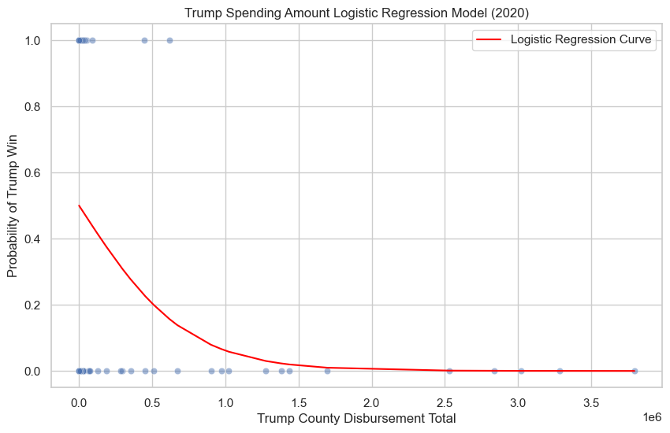

```python
sns.set(style='whitegrid')

plt.figure(figsize=(10, 6))

sns.scatterplot(data=merged_2020, x='disbursement_trump', y='trump_win', alpha=0.5)

X = np.sort(merged_2020['disbursement_trump'])
predicted_probT2020 = logregT2020.predict_proba(X.reshape(-1, 1))[:, 1]

plt.plot(X, predicted_probT2020, color='red', label='Logistic Regression Curve')

plt.title('Trump Spending Amount Logistic Regression Model (2020)')
plt.xlabel('Trump County Disbursement Total')
plt.ylabel('Probability of Trump Win')
plt.legend()
plt.show()
```

```python
print(resultT2020.summary())
```

```
                           Logit Regression Results
==============================================================================
Dep. Variable:              trump_win   No. Observations:                  128
Model:                          Logit   Df Residuals:                      126
Method:                           MLE   Df Model:                            1
Date:                Tue, 05 Nov 2024   Pseudo R-squ.:                  0.1264
Time:                        10:58:59   Log-Likelihood:                -75.183
converged:                       True   LL-Null:                       -86.064
Covariance Type:            nonrobust   LLR p-value:                 3.086e-06
======================================================================================
                         coef    std err          z      P>|z|      [0.025      0.975]
--------------------------------------------------------------------------------------
const                  0.7457      0.204      3.659      0.000       0.346       1.145
disbursement_trump -5.127e-06   2.27e-06     -2.263      0.024   -9.57e-06   -6.86e-07
======================================================================================
```

# 2016 Election: Probability of County Majority Vote as a Function of Disbursement Rate

```python
X = merged_2016[['disbursement_clinton_pct']]
y = merged_2016['clinton_win']
```

```python
X_train, X_test, y_train, y_test = train_test_split(X, y, test_size=0.3, random_state=42)
```

```python
X_train_C2016 = sm.add_constant(X_train)
X_test_C2016 = sm.add_constant(X_test)
```

```python
logit_modelC2016 = sm.Logit(y_train, X_train_C2016)
resultC2016 = logit_modelC2016.fit()
```

```
Optimization terminated successfully.
         Current function value: 0.647993
         Iterations 4
```

```python
y_predC2016 = resultC2016.predict(X_test_C2016)
y_pred_binaryC2016 = [1 if x >= 0.5 else 0 for x in y_predC2016]
```

```python
accuracyC2016 = accuracy_score(y_test, y_pred_binaryC2016)
conf_matrixC2016 = confusion_matrix(y_test, y_pred_binaryC2016)
```

```python
print(f"Accuracy: {accuracyC2016}")
print(f"Confusion Matrix: \n{conf_matrixC2016}")
```

```
Accuracy: 0.6818181818181818
Confusion Matrix:
[[30  0]
 [14  0]]
```

```python
logregC2016 = LogisticRegression(solver='liblinear')
logregC2016.fit(X, y)
```

```
LogisticRegression(solver='liblinear')
```

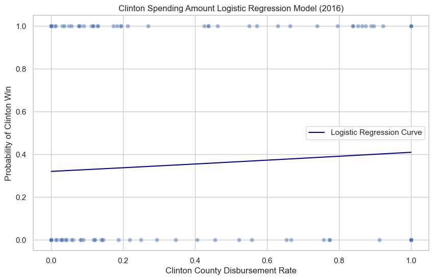

```python
sns.set(style='whitegrid')

plt.figure(figsize=(10, 6))

sns.scatterplot(data=merged_2016, x='disbursement_clinton_pct', y='clinton_win', alpha=0.5)

X = np.sort(merged_2016['disbursement_clinton_pct'])
predicted_probC2016 = logregC2016.predict_proba(X.reshape(-1, 1))[:, 1]

plt.plot(X, predicted_probC2016, color='darkblue', label='Logistic Regression Curve')

plt.title('Clinton Spending Amount Logistic Regression Model (2016)')
plt.xlabel('Clinton County Disbursement Rate')
plt.ylabel('Probability of Clinton Win')
plt.legend()
plt.show()
```

```python
print(resultC2016.summary())
```

```
                           Logit Regression Results
==============================================================================
Dep. Variable:            clinton_win   No. Observations:                  102
Model:                          Logit   Df Residuals:                      100
Method:                           MLE   Df Model:                            1
Date:                Tue, 05 Nov 2024   Pseudo R-squ.:                0.001934
Time:                        11:04:48   Log-Likelihood:                -66.095
converged:                       True   LL-Null:                       -66.223
Covariance Type:            nonrobust   LLR p-value:                    0.6128
============================================================================================
                               coef    std err          z      P>|z|      [0.025      0.975]
--------------------------------------------------------------------------------------------
const                       -0.6944      0.273     -2.548      0.011      -1.229      -0.160
disbursement_clinton_pct     0.2692      0.531      0.508      0.612      -0.771       1.309
============================================================================================
```

```python
X = merged_2016[['disbursement_trump_pct']]
y= merged_2016['trump_win']
```

```python
X_train, X_test, y_train, y_test = train_test_split(X, y, test_size=0.3, random_state=42)
```

```python
X_train_T2016 = sm.add_constant(X_train)
X_test_T2016 = sm.add_constant(X_test)
```

```python
logit_modelT2016 = sm.Logit(y_train, X_train_T2016)
resultT2016 = logit_modelT2016.fit()
```

```
Optimization terminated successfully.
         Current function value: 0.647993
         Iterations 4
```

```python
y_predT2016 = resultT2016.predict(X_test_T2016)
y_pred_binaryT2016 = [1 if x >= 0.5 else 0 for x in y_predT2016]
```

```python
accuracyT2016 = accuracy_score(y_test, y_pred_binaryT2016)
conf_matrixT2016 = confusion_matrix(y_test, y_pred_binaryT2016)
```

```python
print(f"Accuracy: {accuracyT2016}")
print(f"Confusion Matrix: \n{conf_matrixT2016}")
```

```
Accuracy: 0.6590909090909091
Confusion Matrix:
[[ 0 15]
 [ 0 29]]
```

```python
logregT2016 = LogisticRegression(solver='liblinear')
logregT2016.fit(X, y)
```

```
LogisticRegression(solver='liblinear')
```

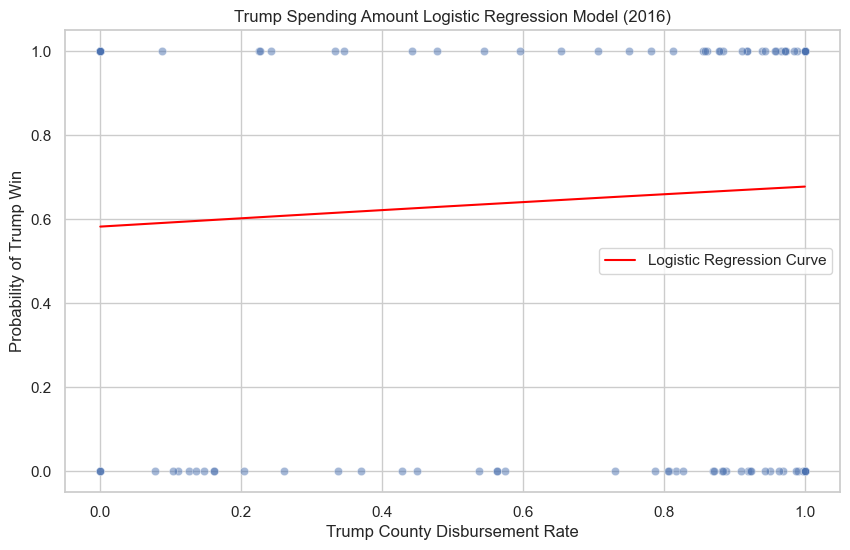

```python
sns.set(style='whitegrid')

plt.figure(figsize=(10, 6))

sns.scatterplot(data=merged_2016, x='disbursement_trump_pct', y='trump_win', alpha=0.5)

X = np.sort(merged_2016['disbursement_trump_pct'])
predicted_probT2016 = logregT2016.predict_proba(X.reshape(-1, 1))[:, 1]

plt.plot(X, predicted_probT2016, color='red', label='Logistic Regression Curve')

plt.title('Trump Spending Amount Logistic Regression Model (2016)')
plt.xlabel('Trump County Disbursement Rate')
plt.ylabel('Probability of Trump Win')
plt.legend()
plt.show()
```

```python
print(resultT2016.summary())
```

```
                           Logit Regression Results
==============================================================================
Dep. Variable:              trump_win   No. Observations:                  102
Model:                          Logit   Df Residuals:                      100
Method:                           MLE   Df Model:                            1
Date:                Tue, 05 Nov 2024   Pseudo R-squ.:                0.001934
Time:                        11:08:31   Log-Likelihood:                -66.095
converged:                       True   LL-Null:                       -66.223
Covariance Type:            nonrobust   LLR p-value:                    0.6128
==========================================================================================
                             coef    std err          z      P>|z|      [0.025      0.975]
------------------------------------------------------------------------------------------
const                      0.4251      0.410      1.037      0.300      -0.379       1.229
disbursement_trump_pct     0.2692      0.531      0.508      0.612      -0.771       1.309
==========================================================================================
```

# 2020 Election: Probability of County Majority Vote as a Function of Disbursement Rate

```python
X = merged_2020[['disbursement_biden_pct']]
y = merged_2020['biden_win']
```

```python
X_train, X_test, y_train, y_test = train_test_split(X, y, test_size=0.3, random_state=42)
```

```python
X_train_B2020 = sm.add_constant(X_train)
X_test_B2020 = sm.add_constant(X_test)
```

```python
logit_modelB2020 = sm.Logit(y_train, X_train_B2020)
resultB2020 = logit_modelB2020.fit()
```

```
Optimization terminated successfully.
         Current function value: 0.640567
         Iterations 4
```

```python
y_predB2020 = resultB2020.predict(X_test_B2020)
y_pred_binaryB2020 = [1 if x >= 0.5 else 0 for x in y_predB2020]
```

```python
accuracyB2020 = accuracy_score(y_test, y_pred_binaryB2020)
conf_matrixB2020 = confusion_matrix(y_test, y_pred_binaryB2020)
```

```python
print(f"Accuracy: {accuracyB2020}")
print(f"Confusion Matrix: \n{conf_matrixB2020}")
```

```
Accuracy: 0.6428571428571429
Confusion Matrix:
[[30  6]
 [14  6]]
```

```python
logregB2020 = LogisticRegression(solver='liblinear')
logregB2020.fit(X, y)
```

```
LogisticRegression(solver='liblinear')
```

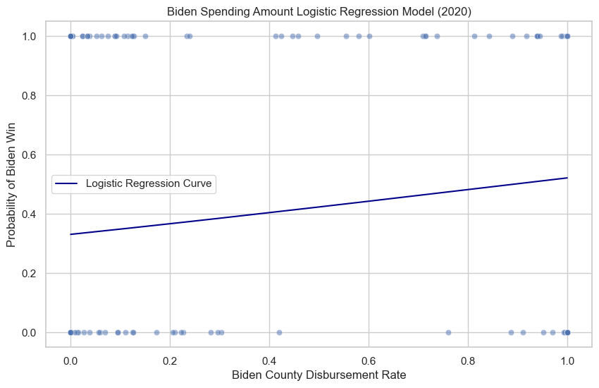

```python
sns.set(style='whitegrid')

plt.figure(figsize=(10, 6))

sns.scatterplot(data=merged_2020, x='disbursement_biden_pct', y='biden_win', alpha=0.5)

X = np.sort(merged_2020['disbursement_biden_pct'])
predicted_probB2020 = logregB2020.predict_proba(X.reshape(-1, 1))[:, 1]

plt.plot(X, predicted_probB2020, color='darkblue', label='Logistic Regression Curve')

plt.title('Biden Spending Amount Logistic Regression Model (2020)')
plt.xlabel('Biden County Disbursement Rate')
plt.ylabel('Probability of Biden Win')
plt.legend()
plt.show()
```

```python
print(resultB2020.summary())
```

```
                           Logit Regression Results
==============================================================================
Dep. Variable:              biden_win   No. Observations:                  128
Model:                          Logit   Df Residuals:                      126
Method:                           MLE   Df Model:                            1
Date:                Tue, 05 Nov 2024   Pseudo R-squ.:                 0.03174
Time:                        11:11:51   Log-Likelihood:                -81.993
converged:                       True   LL-Null:                       -84.680
Covariance Type:            nonrobust   LLR p-value:                   0.02043
==========================================================================================
                             coef    std err          z      P>|z|      [0.025      0.975]
------------------------------------------------------------------------------------------
const                     -0.7798      0.222     -3.514      0.000      -1.215      -0.345
disbursement_biden_pct     1.1371      0.495      2.297      0.022       0.167       2.107
==========================================================================================
```

```python
X = merged_2020[['disbursement_trump_pct']]
y= merged_2020['trump_win']
```

```python
X_train, X_test, y_train, y_test = train_test_split(X, y, test_size=0.3, random_state=42)
```

```python
X_train_T2020 = sm.add_constant(X_train)
X_test_T2020 = sm.add_constant(X_test)
```

```python
logit_modelT2020 = sm.Logit(y_train, X_train_T2020)
resultT2020 = logit_modelT2020.fit()
```

```
Optimization terminated successfully.
         Current function value: 0.657140
         Iterations 4
```

```python
y_predT2020 = resultT2020.predict(X_test_T2020)
y_pred_binaryT2020 = [1 if x >= 0.5 else 0 for x in y_predT2020]
```

```python
accuracyT2020 = accuracy_score(y_test, y_pred_binaryT2020)
conf_matrixT2020 = confusion_matrix(y_test, y_pred_binaryT2020)
```

```python
print(f"Accuracy: {accuracyT2020}")
print(f"Confusion Matrix: \n{conf_matrixT2020}")
```

```
Accuracy: 0.6428571428571429
Confusion Matrix:
[[ 6 14]
 [ 6 30]]
```

```python
logregT2020 = LogisticRegression(solver='liblinear')
logregT2020.fit(X, y)
```

```
LogisticRegression(solver='liblinear')
```

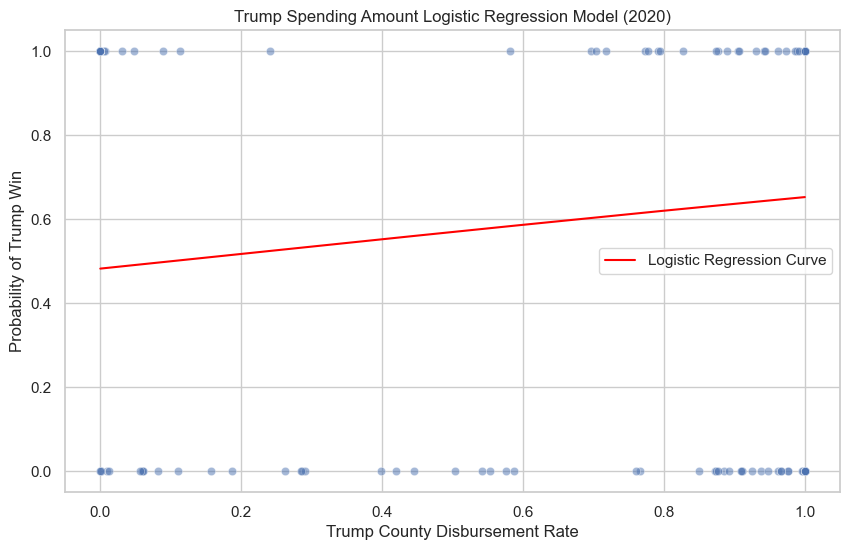

```python
sns.set(style='whitegrid')

plt.figure(figsize=(10, 6))

sns.scatterplot(data=merged_2020, x='disbursement_trump_pct', y='trump_win', alpha=0.5)

X = np.sort(merged_2020['disbursement_trump_pct'])
predicted_probT2020 = logregT2020.predict_proba(X.reshape(-1, 1))[:, 1]

plt.plot(X, predicted_probT2020, color='red', label='Logistic Regression Curve')

plt.title('Trump Spending Amount Logistic Regression Model (2020)')
plt.xlabel('Trump County Disbursement Rate')
plt.ylabel('Probability of Trump Win')
plt.legend()
plt.show()
```

```python
print(resultT2020.summary())
```

```
                           Logit Regression Results
==============================================================================
Dep. Variable:              trump_win   No. Observations:                  128
Model:                          Logit   Df Residuals:                      126
Method:                           MLE   Df Model:                            1
Date:                Tue, 05 Nov 2024   Pseudo R-squ.:                 0.02266
Time:                        11:14:04   Log-Likelihood:                -84.114
converged:                       True   LL-Null:                       -86.064
Covariance Type:            nonrobust   LLR p-value:                   0.04829
==========================================================================================
                             coef    std err          z      P>|z|      [0.025      0.975]
------------------------------------------------------------------------------------------
const                     -0.3273      0.418     -0.783      0.433      -1.146       0.492
disbursement_trump_pct     0.9629      0.491      1.960      0.050    9.39e-05       1.926
==========================================================================================
```

# Discussion of Results

We see statistically significant coefficient correlation when evaluating disbursement amount as our independent variable. However, the explanation of variance is fairly low. When using disbursement rate as independent variable, correlation sometimes remains strong. However, explanation of variance is extremely low. For our models examining disbursement totals, outliers may be skewing results. The issue with disbursement rate as our variable is that there are majority win/loss values for both extreme ends of spending at 0 or 100%.